# (Poorly) estimating species richness from Atlas of Living Australia data

Maps

Multispecies

Martin Westgate  
2021-05-20

[figure not shown]

#### Author:

Martin Westgate

#### Date:

20 May, 2021

# Get map data

First load the required packages

```r
# libraries
library(raster)
library(terra)
# library(rasterVis)
library(pbapply)

library(ggplot2)
library(viridis)
library(ggtext)
```

Get WorldClim maps, which include environmental predictors we will use later in our model

```r
worldclim <- rast(
  getData("worldclim", var = "bio", res = 10, path = "data"))
```

Subset to Australia

```r
bbox <- ext(c(110, 155, -45, -10))
aus <- crop(worldclim, bbox)
```

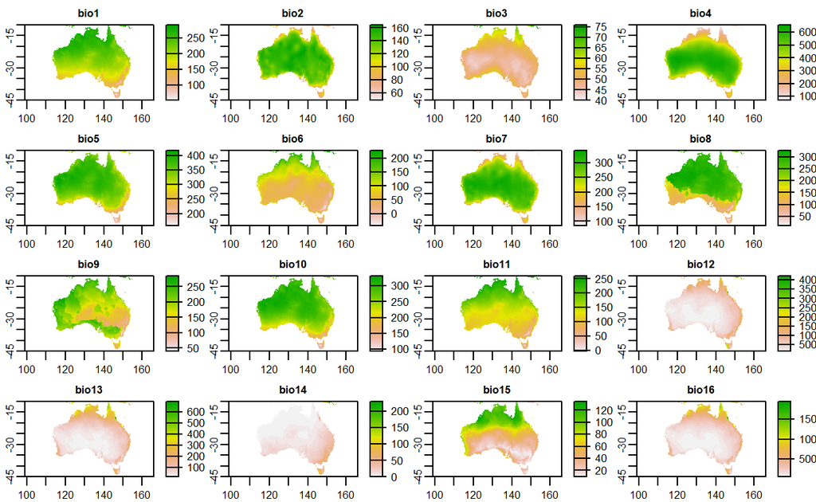

```r
plot(aus)
```

# Download ALA data

Next we’ll do something a little creative - we will create a grid of points that make up the map of Australia. We will then use these points to extract data from the Atlas of Living Australia.

First we create a grid to lookup ALA records

```r
grid <- expand.grid(
  xmin = c(100:154),
  ymin = c(-45:-9))
grid$xmax <- grid$xmin + 1
grid$ymax <- grid$ymin + 1
```

Subset to those over the australian land mass

```r
point_values <- extract(aus, grid[, c("xmin", "ymin")] + 0.5)
keep_rows <-
  !apply(point_values[, -1], 1, function(a){all(is.na(a))}) &
  !(grid$ymin >= -11 & grid$xmin != 142) & # excludes offshore stuff
  !(grid$ymin == -12 & grid$xmin > 150)
grid <- grid[keep_rows, ]
point_values <- point_values[keep_rows, ]
```

We can check that it works by plotting the points

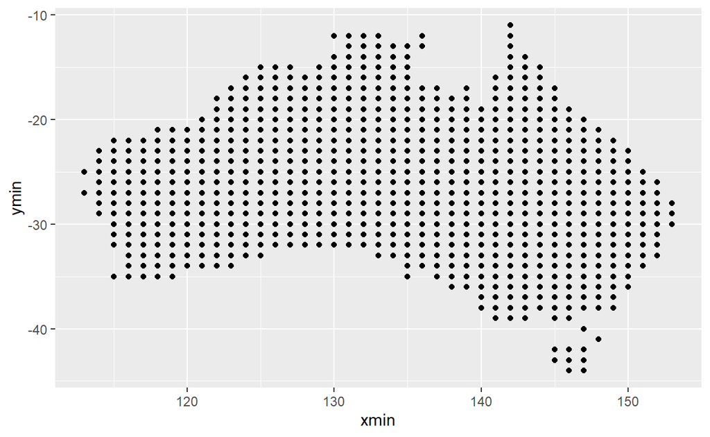

```r
ggplot(grid, aes(x = xmin, y = ymin)) + geom_point() # works
```

Now we build a function to paste values we are about to extract in a usable mapping format

```r
wkt_list <- lapply(
  split(grid, seq_len(nrow(grid))),
  function(a){
    wkt <- paste0("POLYGON((",
      paste(
        paste(
          c(a$xmin, a$xmax, a$xmax, a$xmin, a$xmin),
          c(a$ymin, a$ymin, a$ymax, a$ymax, a$ymin),
          sep = " "),
        collapse = ","),
    "))")
  })
```

We will use the [galah](https://atlasoflivingaustralia.github.io/galah/index.html) package to download counts of records across Australia.

(If running this code yourself, you also need to set an email associated with your data download request, substituting your email with `myemail@email.com`)

```r
library(galah)
ala_config(email = "myemail@email.com")
```

We can now use `pblapply()` to feed our grid points into `ala_counts()` and extract counts data for each of our grid points (warning: These functions download A LOT of data, so be prepared for long wait times)

```r
point_values$richness <- unlist(pblapply(wkt_list,
  function(a){
    ala_counts(location = select_locations(a), type = "species")
  }))

point_values$records <- unlist(pblapply(wkt_list,
  function(a){
    ala_counts(location = select_locations(a), type = "record")
  }))

# save data
point_values <- cbind(point_values, grid)
```

# Build a model of species richness

Now we can create a linear model to predict values based on the data we have in our grid and some WorldClim environmental predictors.

First we can write the formula

```r
# try an actual model using lm
initial_formula <- formula(paste0(
  "richness ~ scale(log(records)) + ",
  paste(paste0("bio", seq_len(19)), collapse = " + ")
))

initial_formula
```

```
richness ~ scale(log(records)) + bio1 + bio2 + bio3 + bio4 +
    bio5 + bio6 + bio7 + bio8 + bio9 + bio10 + bio11 + bio12 +
    bio13 + bio14 + bio15 + bio16 + bio17 + bio18 + bio19
```

We use this formula in our general linear model

```r
model <- step(glm(initial_formula,
  family = poisson(link = "log"),
  data = point_values))
```

```
Start:  AIC=77139.39
richness ~ scale(log(records)) + bio1 + bio2 + bio3 + bio4 +
    bio5 + bio6 + bio7 + bio8 + bio9 + bio10 + bio11 + bio12 +
    bio13 + bio14 + bio15 + bio16 + bio17 + bio18 + bio19


Step:  AIC=77139.39
richness ~ scale(log(records)) + bio1 + bio2 + bio3 + bio4 +
    bio5 + bio6 + bio8 + bio9 + bio10 + bio11 + bio12 + bio13 +
    bio14 + bio15 + bio16 + bio17 + bio18 + bio19

                      Df Deviance    AIC
<none>                      70603  77139
- bio10                1    70607  77141
- bio17                1    70607  77141
- bio12                1    70609  77143
- bio3                 1    70660  77194
- bio14                1    70663  77197
- bio8                 1    70756  77290
- bio19                1    70881  77415
- bio16                1    70933  77467
- bio9                 1    70982  77516
- bio11                1    71210  77744
- bio13                1    71380  77914
- bio4                 1    71381  77915
- bio2                 1    71540  78074
- bio6                 1    71549  78083
- bio15                1    71656  78190
- bio1                 1    71796  78330
- bio18                1    71820  78354
- bio5                 1    73405  79939
- scale(log(records))  1   345359 351893
```

We then add the coefficients to a list so that we can add the model information to our grid points

```r
# summary(model)
model_coefs <- as.list(coef(model))
# point_values$predicted <- predict(model)

# multiply out
model_list <- rast(lapply(
  names(model_coefs)[-c(1, 2)], function(a){
    aus[[a]] * model_coefs[[a]]
  }))


aus_surface <- sum(model_list) + model_coefs[[1]]
```

We can use a base R plot to see how our new grid surface looks

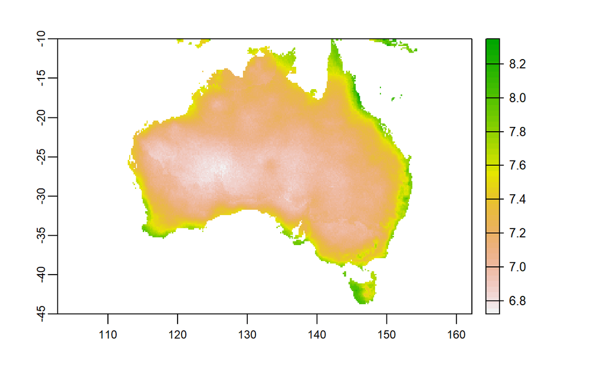

```r
plot(aus_surface)
```

# Make a map

To create a nicer plot, we can calculate the coordinates for our aus surface and use `ggplot()`

```r
# try to plot natively with ggplot2
raster_df <- as.data.frame(coords(aus_surface))
raster_df$prediction <- as.data.frame(aus_surface)$sum
raster_df$prediction_exp <- exp(raster_df$prediction)
# saveRDS(raster_df, "./data/raster_df.rds")
```

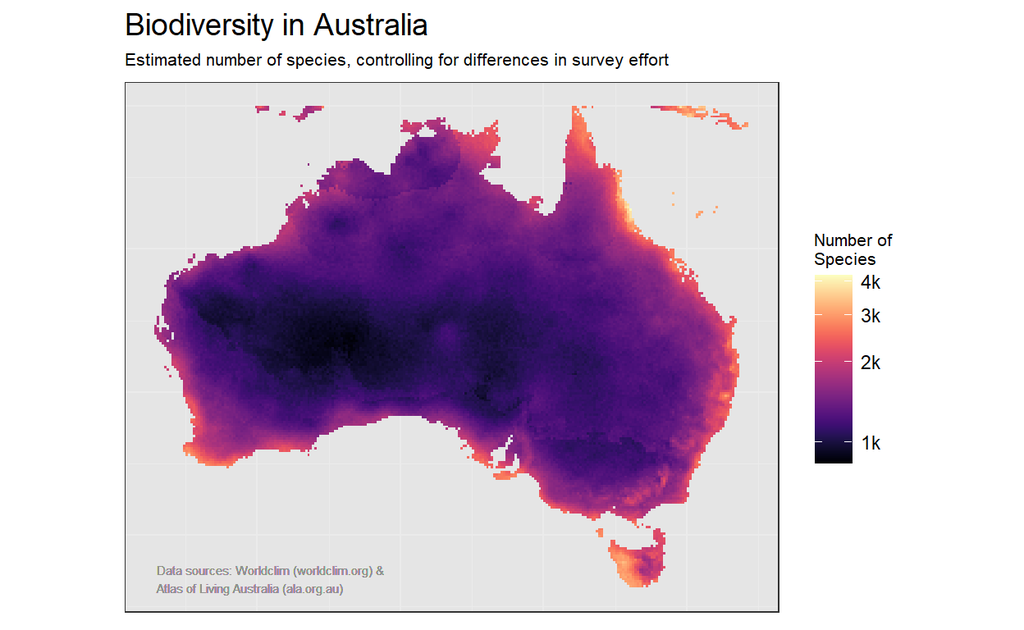

```r
p <- ggplot(raster_df, aes(x = x, y = y, fill = prediction_exp)) +
  geom_tile() +
  coord_equal() +
  scale_fill_viridis(
    trans = "log",
    breaks = seq_len(4) * 1000,
    labels = paste0(seq_len(4), "k"),
    option = "magma") +
  geom_text(
    x = 113, y = -43,
    label = "Data sources: Worldclim (worldclim.org) &\nAtlas of Living Australia (ala.org.au)",
    size = 2,
    color = "#919191",
    hjust = 0
  ) +
  labs(
    x = "Longitude",
    y = "Latitude",
    fill = "Number of\nSpecies",
    title = "Biodiversity in Australia<br>
      <span style='font-size:8pt;'>Estimated number of species, controlling for differences in survey effort</span>"
  ) +
  theme_bw() +
  theme(
    panel.background = element_rect(fill = "grey90", color = NA),
    plot.title =  element_textbox_simple(
      size = 14, lineheight = 1, padding = margin(0, 0, 5, 0)),
    axis.title = element_blank(), # element_text(size = 10),
    axis.text = element_blank(),
    axis.ticks = element_blank(),
    legend.title = element_text(size = 8)# , color = "#919191")
  )

p
```

See the the [original R script](https://github.com/AtlasOfLivingAustralia/science/blob/main/comms/2021-05_spp_richness/species_richness_map.R)